# A3 - Data set Pathway and Network Analysis

YunyiCheng

2024-04-02

## 1. Introduction

This notebook was developed by *Yunyi Cheng* and runs under Docker image in the BCB420 GitHub repository. We will be using `BiocManager` to access the bioconductor project package repository (Morgan and Ramos 2023).

### 1.1 Recap for Assignment #1 and Assignment #2

In Assignment #1, we cleaned and normalized a dataset from a recent study on sex-dependent gene expression changes in Parkinson’s disease(PD) (Tranchevent, Halder, and Glaab 2023). We downloaded the dataset ( GEO id **GSE168496**) and cleaned incorrect values, duplicates, and data points which could not be mapped to HUGO symbols. Furthermore, we reformatted the data frame so that its column name contains metadata information. Afterwards, we normalized it and performed some statistical measures. The final cleaned dataset awaiting further analysis has coverage of 28904 genes and contains 16 samples, with the following conditions:

|  | Ctrl | PD |
| --- | --- | --- |
| Male | 5 | 5 |
| Female | 3 | 3 |

For more information regarding Assignment #1, please consult its [R Notebook](https://github.com/bcb420-2024/Yunyi_Cheng/wiki/Assignment-%231:-Document).

In Assignment #2, we took the normalized expression data that was created in Assignment #1 and rank the genes according to differential expression. There are 240 differentially expressed genes with p-value < 0.05 and 11 genes have FDR < 0.1. After the list was ranked we performed thresholded over-representation analysis to highlight dominant themes in our top set of genes using G:Profiler. With thresholds FDR < 0.1, term size <= 200, and |logFC| > 0.25, there are 92 genes in total, with 91 genes being up-regulated 1 gene being down-regulated.

For more information regarding Assignment #2, please consult its [R Notebook](https://github.com/bcb420-2024/Yunyi_Cheng/wiki/Assignment-%232:-Document).

### 1.2 Tasks for for Assignment #3

In this notebook, we will take the ranked data that was created in Assignment #2 and perform a non-thresholded pathway analysis.

## 2. Non-thresholded Gene set Enrichment Analysis

We will now conduct non-thresholded gene set enrichment analysis using the ranked set of genes from Assignment #2.

### 2.1 Load and Proprocess Data

**What method did you use? What genesets did you use? Make sure to specify versions and cite your methods.**

In this analysis, non-thresholded gene set enrichment analysis (GSEA) was conducted using the `fgsea` package (version `1.28.0`) in R (Korotkevich, Sukhov, and Sergushichev 2019). This approach is different from thresholded analyses because it considers the entire distribution of gene expression changes, rather than focusing solely on those genes that surpass a specific significance threshold. Thus, this method is its able to capture subtle yet meaningful patterns of expression across a broad set of genes, which might be overlooked in a thresholded analysis.

```r
# Load the DEG results from Assignment #2
deg_results <- read.table(file = "./DEG_results.txt", header = TRUE, sep = "\t")

# Make sure PValue and logFC are numeric
deg_results$PValue <- as.numeric(deg_results$PValue)
deg_results$logFC <- as.numeric(deg_results$logFC)

# Add a new column to the data frame for the signed rank
deg_results$signed_rank <- -log10(deg_results$PValue) * sign(deg_results$logFC)

# Coerce the signed rank to be numeric
deg_results$signed_rank <- as.numeric(deg_results$signed_rank)

# Create a ranked list of genes for fgsea
# Note: names of the ranked list - gene names, values - signed ranks
ranked_genes <- data.frame(gene_name = rownames(deg_results), rank = deg_results$signed_rank)
ranked_genes <- ranked_genes[order(-ranked_genes$rank),]
ranked_genes$rank <- as.numeric(ranked_genes$rank)

# Save ranked list
write.table(ranked_genes, "./ranked_genes.rnk",
            quote=FALSE,
            sep='\t',
            row.names = FALSE)

# Process ranked_gene for fgsea
rank_fgsea <- as.numeric(ranked_genes$rank)
names(rank_fgsea) <- ranked_genes$gene_name
```

```r
# Define the path to the GMT file
gmt_path <- "./Human_GOBP_AllPathways_noPFOCR_no_GO_iea_March_01_2024_symbol.gmt"

bader_geneset <- gmtPathways(gmt_path)
```

### 2.2 Run GSEA

Now we can run GSEA through `fgsea` package.

```r
# Run fgsea
fgsea_results <- fgsea(pathways = bader_geneset,
                       stats = rank_fgsea,
                       nperm = 1000,
                       minSize = 15,
                       maxSize = 200)

# Look at the top results
top_fgsea_results <- fgsea_results[order(fgsea_results$padj), ][1:10,]

# Print the top significant pathways
print(top_fgsea_results)
```

```
##                                                                                                                                      pathway
##                                                                                                                                       <char>
##  1:                                     HALLMARK_EPITHELIAL_MESENCHYMAL_TRANSITION%MSIGDBHALLMARK%HALLMARK_EPITHELIAL_MESENCHYMAL_TRANSITION
##  2:                                                                                   HALLMARK_COMPLEMENT%MSIGDBHALLMARK%HALLMARK_COMPLEMENT
##  3:                                                         HALLMARK_TNFA_SIGNALING_VIA_NFKB%MSIGDBHALLMARK%HALLMARK_TNFA_SIGNALING_VIA_NFKB
##  4:                                                             HALLMARK_INFLAMMATORY_RESPONSE%MSIGDBHALLMARK%HALLMARK_INFLAMMATORY_RESPONSE
##  5:                                                     HALLMARK_INTERFERON_GAMMA_RESPONSE%MSIGDBHALLMARK%HALLMARK_INTERFERON_GAMMA_RESPONSE
##  6:                                                         HALLMARK_IL6_JAK_STAT3_SIGNALING%MSIGDBHALLMARK%HALLMARK_IL6_JAK_STAT3_SIGNALING
##  7:                                                                           HALLMARK_UV_RESPONSE_UP%MSIGDBHALLMARK%HALLMARK_UV_RESPONSE_UP
##  8:                                                                                    PID_INTEGRIN1_PATHWAY%MSIGDB_C2%PID_INTEGRIN1_PATHWAY
##  9: INTEGRIN FAMILY CELL SURFACE INTERACTIONS%PATHWAY INTERACTION DATABASE NCI-NATURE CURATED DATA%INTEGRIN FAMILY CELL SURFACE INTERACTIONS
## 10:   BETA3 INTEGRIN CELL SURFACE INTERACTIONS%PATHWAY INTERACTION DATABASE NCI-NATURE CURATED DATA%BETA3 INTEGRIN CELL SURFACE INTERACTIONS
##            pval      padj         ES       NES nMoreExtreme  size
##           <num>     <num>      <num>     <num>        <num> <int>
##  1: 0.004201681 0.3377914 -0.5233264 -1.760569            0   143
```

[output cut: 21 more lines]

```r
fgsea_results[NES > 0][order(fgsea_results[NES > 0]$padj), ]
```

| pathway | pval | padj | ES | NES | nMoreExtreme | size | leadingEdge |
| --- | --- | --- | --- | --- | --- | --- | --- |
| INFLUENZA VIRAL RNA TRANSCRIPTION AND REPLICATION%REACTOME%R-HSA-168273.5 | 0.001314060 | 0.3377914 | 0.6207795 | 1.8261738 | 0 | 129 |  |
| ROLE OF LAT2 NTAL LAB ON CALCIUM MOBILIZATION%REACTOME%R-HSA-2730905.4 | 0.001434720 | 0.3377914 | 0.7037314 | 1.9070859 | 0 | 71 |  |
| CREATION OF C4 AND C2 ACTIVATORS%REACTOME DATABASE ID RELEASE 65%166786 | 0.001408451 | 0.3377914 | 0.6783969 | 1.8673254 | 0 | 76 |  |
| PRE-MRNA SPLICING%REACTOME DATABASE ID RELEASE 65%72163 | 0.001265823 | 0.3377914 | 0.6054662 | 1.8432650 | 0 | 199 |  |
| CD22 MEDIATED BCR REGULATION%REACTOME%R-HSA-5690714.4 | 0.004285714 | 0.3377914 | 0.6912731 | 1.8641722 | 2 | 66 |  |
| INFLUENZA INFECTION%REACTOME%R-HSA-168255.6 | 0.001302083 | 0.3377914 | 0.6277162 | 1.8632357 | 0 | 149 |  |
| ROLE OF PHOSPHOLIPIDS IN PHAGOCYTOSIS%REACTOME DATABASE ID RELEASE 65%2029485 | 0.002812940 | 0.3377914 | 0.6790526 | 1.8996325 | 1 | 87 |  |
| SRP-DEPENDENT COTRANSLATIONAL PROTEIN TARGETING TO MEMBRANE%REACTOME%R-HSA-1799339.4 | 0.004016064 | 0.3377914 | 0.6190767 | 1.7916895 | 2 | 109 |  |
| REGULATION OF HSF1-MEDIATED HEAT SHOCK RESPONSE%REACTOME DATABASE ID RELEASE 65%3371453 | 0.004273504 | 0.3377914 | 0.6819077 | 1.8462256 | 2 | 68 |  |
| FCGR ACTIVATION%REACTOME DATABASE ID RELEASE 65%2029481 | 0.001422475 | 0.3377914 | 0.6682042 | 1.8247600 | 0 | 73 |  |

[output cut: 3907 more lines]

**Table 1: Positively Enriched Gene Sets.** It lists gene sets that show positive normalized enrichment scores (NES) indicative of genes upregulated in PD compared to control, considering both males and females. Gene sets are ordered by their adjusted p-values (padj) in ascending order, showing the most statistically significant pathways at the top.

```r
fgsea_results[NES < 0][order(fgsea_results[NES < 0]$padj), ]
```

| pathway | pval | padj | ES | NES | nMoreExtreme | size | leadingEdge |
| --- | --- | --- | --- | --- | --- | --- | --- |
| HALLMARK_EPITHELIAL_MESENCHYMAL_TRANSITION%MSIGDBHALLMARK%HALLMARK_EPITHELIAL_MESENCHYMAL_TRANSITION | 0.004201681 | 0.3377914 | -0.5233264 | -1.7605689 | 0 | 143 |  |
| HALLMARK_COMPLEMENT%MSIGDBHALLMARK%HALLMARK_COMPLEMENT | 0.004237288 | 0.3377914 | -0.4862935 | -1.6063400 | 0 | 135 |  |
| HALLMARK_TNFA_SIGNALING_VIA_NFKB%MSIGDBHALLMARK%HALLMARK_TNFA_SIGNALING_VIA_NFKB | 0.004184100 | 0.3377914 | -0.5940903 | -2.0325725 | 0 | 157 |  |
| HALLMARK_INFLAMMATORY_RESPONSE%MSIGDBHALLMARK%HALLMARK_INFLAMMATORY_RESPONSE | 0.004545455 | 0.3377914 | -0.5078970 | -1.7372752 | 0 | 170 |  |
| HALLMARK_INTERFERON_GAMMA_RESPONSE%MSIGDBHALLMARK%HALLMARK_INTERFERON_GAMMA_RESPONSE | 0.004405286 | 0.3377914 | -0.5195830 | -1.7799775 | 0 | 164 |  |
| HALLMARK_IL6_JAK_STAT3_SIGNALING%MSIGDBHALLMARK%HALLMARK_IL6_JAK_STAT3_SIGNALING | 0.003424658 | 0.3377914 | -0.5213010 | -1.5825653 | 0 | 76 |  |
| HALLMARK_UV_RESPONSE_UP%MSIGDBHALLMARK%HALLMARK_UV_RESPONSE_UP | 0.003937008 | 0.3377914 | -0.4811865 | -1.5799786 | 0 | 122 |  |
| PID_INTEGRIN1_PATHWAY%MSIGDB_C2%PID_INTEGRIN1_PATHWAY | 0.003030303 | 0.3377914 | -0.6777925 | -1.8686262 | 0 | 47 |  |
| INTEGRIN FAMILY CELL SURFACE INTERACTIONS%PATHWAY INTERACTION DATABASE NCI-NATURE CURATED DATA%INTEGRIN FAMILY CELL SURFACE INTERACTIONS | 0.002832861 | 0.3377914 | -0.7462645 | -1.8243648 | 0 | 26 |  |
| BETA3 INTEGRIN CELL SURFACE INTERACTIONS%PATHWAY INTERACTION DATABASE NCI-NATURE CURATED DATA%BETA3 INTEGRIN CELL SURFACE INTERACTIONS | 0.002958580 | 0.3377914 | -0.7136987 | -1.9534874 | 0 | 43 |  |

[output cut: 2362 more lines]

**Table 2: Negatively Enriched Gene Sets.** They are pathways enriched among genes downregulated in Parkinson’s disease compared to control. They are also sorted by increasing adjusted p-values (padj), with pathways demonstrating the highest significance displayed at the top.

### 2.3 Discussions

**How do these results compare to the results from the thresholded analysis in Assignment #2. Compare qualitatively. Is this a straight forward comparison? Why or why not?**

A non-thresholded analysis includes all genes in the ranking process, which allows for the identification of subtle yet consistent changes in gene expression across a pathway. In contrast, a thresholded analysis in Assignment #2 focuses on genes that surpass a certain cutoff in expression changes, potentially missing out on these subtle changes. These analysis do have results in common like pathways of ribosomal processes and gene RPS4Y1 that may inpact neurodegeneration, a significant biomarker for PD (Sun et al. 2014). The comparison is not straightforward as we are comparing specific genes with gene sets ana pathways. Both methods provide valuable and complementary insights. The thresholded analysis identifies strong individual gene signals, whereas non-thresholded GSEA captures broader effects across gene sets.

## 3. Visualize Geneset Enrichment Analysis in Cytoscape

### 3.1 Original Enrichment Map

**Create an enrichment map - how many nodes and how many edges in the resulting map? What thresholds were used to create this map? Make sure to record all thresholds. Include a screenshot of your network prior to manual layout.**

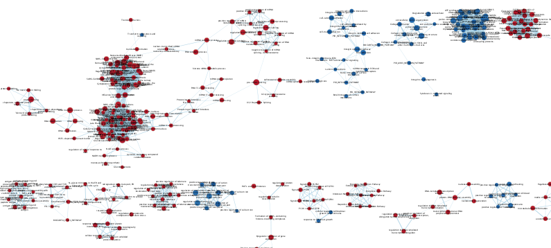

**Figure 1. Screenshot of Enrichment Map before Manual Layout.** This network visualization displays the clustered gene sets with red nodes indicating upregulated gene sets and blue nodes indicating downregulated gene sets in PD condition. The size of each node corresponds to the gene set size, and the thickness of the edges reflects the degree of overlap between the gene sets. Legend credit to (Reimand et al. 2019).

There are 1290 nodes and 4620 edges in the resulting map. Since there are four conditions (male/female, PD/control), and filters too stringent may result in insufficient amount of node and edges for further analysis, I relaxed the FDR Q-value to be 0.5. The complete set of threshold used is shown below:

[output not shown]

### 3.2 Annotated Enrichment Map

**Annotate your network - what parameters did you use to annotate the network. If you are using the default parameters make sure to list them as well.**

I used AutoAnnotate, which is part of EnrichmentMap pipeline workflow. The detailed parameter settings are shown below:

| Option Category | Parameter | Setting or Value |
| --- | --- | --- |
| Cluster Options | Use clusterMaker App | Yes |
| Cluster Options | Cluster algorithm | MCL Cluster |
| Cluster Options | Edge weight column | similarity_coefficient |
| Cluster Options | Create singleton clusters | No |
| Cluster Options | Layout network to prevent cluster overlap | Yes |
| Label Options | Label Column | GS_DESCR |
| Label Options | Label Algorithm | WordCloud: Adjacent Words (default) |
| Label Options | Max words per label | 3 |
| Label Options | Minimum word occurrence | 1 |
| Label Options | Adjacent word bonus | 8 |

We relaxed the threshold for Q-value in the previous section, allowing for more meaningful information to be included. Now we can restrict the threshold a little more to exclude some noise nodes, and I set the Q-value threshold to be 0.3 (other threshold remain the same). Below is the annotated enrichment map prior to manual modification.

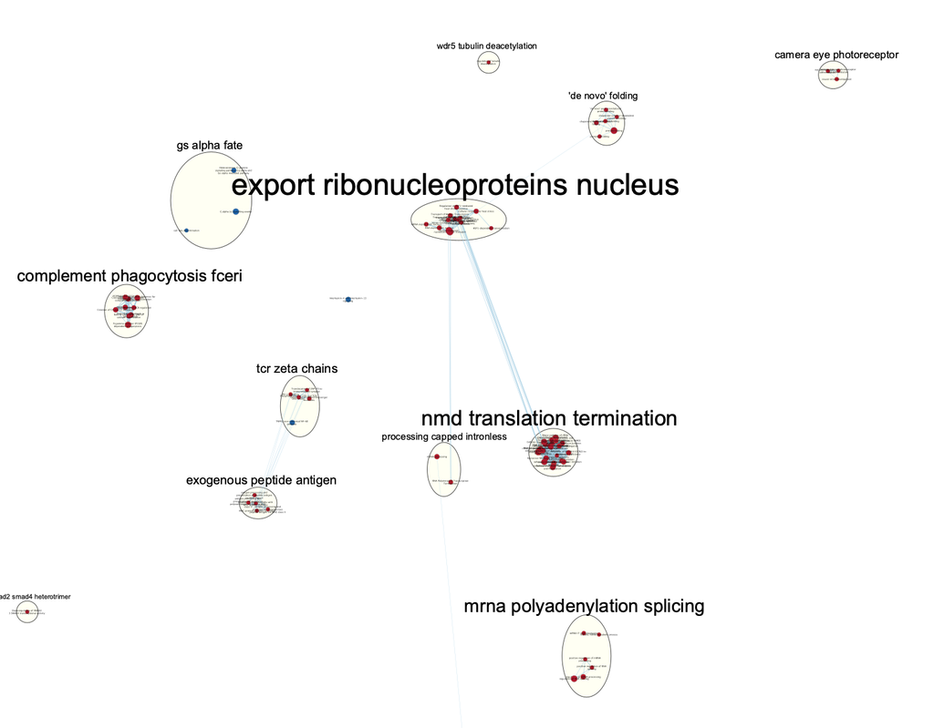

**Figure 2. Annotated Enrichment Map before Manual Modification.** Significant clusters within the network, with annotations highlighting the dominant biological processes or pathways represented by each cluster. The size of each node corresponds to the gene set size, and the thickness of the edges reflects the degree of overlap between the gene sets. Legend credit to (Reimand et al. 2019).

### 3.3 Publication-ready Figure

**Make a publication ready figure - include this figure with proper legends in your notebook.**

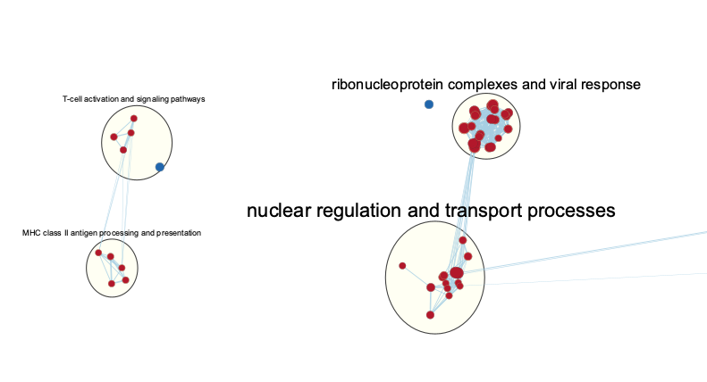

### 3.4 Theme Network

**Collapse your network to a theme network. What are the major themes present in this analysis? Do they fit with the model? Are there any novel pathways or themes?**

The major themes present in this analysis seem to be nuclear regulation and transport processes, ribunucleoprotein complexes and viral response, and T-cell activation & signalling pathways. They fit with the previous model. Comparing the result with Assignment #2, we can see that most of the genes are involved in biological processes (like pre and post synaptic assembly) and reactome (like T-cell activation).

There is a novel theme worth noting, that is ribunucleoprotein complexes and viral response.

## 4. Interpretation and detailed view of results

### 4.1 Interpretation

**Do the enrichment results support conclusions or mechanism discussed in the original paper? How do these results differ from the results you got from Assignment #2 thresholded methods?**

Overall, the paper revealed significant sex disparities in PD-associated transcriptomic changes, resulting in coordinated modulations of molecular processes. The main finding of the original is the identification of significant sex differences in Parkinson’s disease (PD)-associated transcriptomic changes in the brain, with a particular focus on mitochondrial pathways and specific regulatory factors like NR4A2.

**Can you find evidence (i.e., publications) to support some of the results that you see? How does this evidence support your result?**

Most of the themes we found in enrichment map are supported by the original paper, I would like to focus on the novel theme we discovered in this assignment. Viral infections are known to affect protein aggregation, a common feature in neurodegenerative disorders. An article by (Leblanc and Vorberg 2022) provides supporting details. For instance, influenza-A, flaviviruses, and herpesviruses have been shown to induce acute or chronic Parkinson-like symptoms or post-encephalitic parkinsonism. Moreover, infections with hepatitis C and B viruses (HCV and HBV) have been linked to an increased risk of developing PD. In experimental models, mice infected with a neurotropic influenza-A virus exhibited α-Synuclein inclusions in dopaminergic neurons, highlighting the direct impact of viral infections on processes leading to protein aggregation in neurodegenerative diseases.

### 4.1 Dark Matter Analysis

```r
gmt_file <- file.path("./Human_GOBP_AllPathways_noPFOCR_no_GO_iea_March_01_2024_symbol.gmt")
capture.output(genesets <- GSA.read.gmt(gmt_file),file="gsa_load.out")
names(genesets$genesets) <- genesets$geneset.names
```

```r
expression <- read.table(file = "./a1NormalizedCpmDf.csv",
                         header = TRUE, sep = ",", stringsAsFactors = FALSE)
ranks <- read.table(file = "./ranked_genes.rnk",
                    header = TRUE, sep = "\t", quote="\"",
                    stringsAsFactors = FALSE)
```

```r
# 2 gsea results files
enr_file1 <- read.table(file = "./formatted_gsea_report_pos.tsv",
                        header = TRUE, sep = "\t", quote="\"",
                        stringsAsFactors = FALSE,row.names=1)
enr_file2 <- read.table(file = "formatted_gsea_report_neg.tsv",
                        header = TRUE, sep = "\t", quote="\"",
                        stringsAsFactors = FALSE,row.names=1)

# Calculate q-values
enr_file1$qval <- p.adjust(enr_file1$pval, method = "fdr")
enr_file2$qval <- p.adjust(enr_file2$pval, method = "fdr")
```

```r
FDR_threshold <- 0.1
# Get the genes from the set of enriched pathway (no matter what threshold)
all_sig_enr_genesets<- c(rownames(enr_file1)[which(enr_file1[,"qval"]<=FDR_threshold)], rownames(enr_file2)[which(enr_file2[,"qval"]<=FDR_threshold)])

genes_sig_enr_gs <- c()
for(i in 1:length(all_sig_enr_genesets)){
  current_geneset <- unlist(genesets$genesets[which(genesets$geneset.names %in% all_sig_enr_genesets[i])])
  genes_sig_enr_gs <- union(genes_sig_enr_gs, current_geneset)
}
```

```r
genes_all_gs <- unique(unlist(genesets$genesets))
```

```r
diff_expr_genes <- rownames(deg_results[deg_results$FDR < 0.1, ])
# Get the set of genes that have no annotation
genes_no_annotation <- setdiff(diff_expr_genes, genes_all_gs)
genes_no_annotation_enriched <- setdiff(diff_expr_genes, genes_sig_enr_gs)

# Print the number of enriched genes with no annotation
cat("Number of genes with no annotation:", length(genes_no_annotation), "\n")
```

```
## Number of genes with no annotation: 0
```

```r
if(length(genes_no_annotation) > 0) {
  cat("Examples of genes with no annotation:", head(genes_no_annotation), "\n")
}

cat("Number of enriched genes with no annotation:", length(genes_no_annotation_enriched), "\n")
```

```
## Number of enriched genes with no annotation: 11
```

```r
if(length(genes_no_annotation_enriched) > 0) {
  cat("Examples of enriched genes with no annotation:", head(genes_no_annotation_enriched), "\n")
}
```

```
## Examples of enriched genes with no annotation: RPS4Y1 EIF1AY USP9Y ZFY NLGN4Y KDM5D
```

```r
# Indices of DE genes not included in enriched gene lists
no_annotation_enriched_idx <- which(rownames(expression) %in% genes_no_annotation_enriched)
cat("Indices of differentially expressed genes not included in enriched gene lists:\n")
```

```
## Indices of differentially expressed genes not included in enriched gene lists:
```

```r
cat(paste(no_annotation_enriched_idx, collapse = ", "))
```

As we can see that, there is no over lap between DEGs with the enriched gene lists. The absence of indices for such DEGs suggests that the DEGs are not part of the gene sets that were considered significantly enriched in the analysis. Enrichment analysis often focuses on genes that collectively show a pattern of expression indicative of certain biological functions or processes, which may not include every DEG. This is uncommon, but I think this might have something to do with the complexity and multifactorial nature of this study.

## 5. References

Korotkevich, Gennady, Vladimir Sukhov, and Alexey Sergushichev. 2019. “Fast Gene Set Enrichment Analysis.” *bioRxiv*. https://doi.org/10.1101/060012.

Leblanc, Pascal, and Ina Maja Vorberg. 2022. “Viruses in Neurodegenerative Diseases: More Than Just Suspects in Crimes.” *PLoS Pathog* 18 (8): e1010670. https://doi.org/10.1371/journal.ppat.1010670.

Merico, Ruth AND Stueker, Daniele AND Isserlin. 2010. “Enrichment Map: A Network-Based Method for Gene-Set Enrichment Visualization and Interpretation.” *PLOS ONE* 5 (11): 1–12. https://doi.org/10.1371/journal.pone.0013984.

Morgan, Martin, and Marcel Ramos. 2023. *BiocManager: Access the Bioconductor Project Package Repository*. https://CRAN.R-project.org/package=BiocManager.

Reimand, Jüri, Ruth Isserlin, Veronique Voisin, Mike Kucera, Christian Tannus-Lopes, Asha Rostamianfar, Lina Wadi, et al. 2019. “Pathway Enrichment Analysis and Visualization of Omics Data Using g:profiler, GSEA, Cytoscape and EnrichmentMap.” *Nature Protocols* 14 (2): 482–517. https://doi.org/10.1038/s41596-018-0103-9.

Sun, Ai Guo, Jie Wang, Ya Ze Shan, Wen Juan Yu, Xin Li, Cong Hong Cong, and Xun Wang. 2014. “Identifying Distinct Candidate Genes for Early Parkinson’s Disease by Analysis of Gene Expression in Whole Blood.” *Neuro Endocrinology Letters* 35 (5): 398–404.

Tranchevent, Léon-Charles, Rashi Halder, and Enrico Glaab. 2023. “Systems Level Analysis of Sex-Dependent Gene Expression Changes in Parkinson’s Disease.” *NPJ Parkinson’s Disease* 9 (1): 8. https://doi.org/10.1038/s41531-023-00446-8.